# Final Project: Linear Analysis of Poverty Rate on Material Footprint per Capita

Author

Ethan Gutterman, Joshua Aguilar, Kaden Emerson, Dominic Tangaan

# 1 Data Description and Initial Assumptions

The two datasets, that will be analyzed with a linear model, included the extreme poverty rates of 159 countries, defined as the percentage of people with an income below $2.15 per day, and the material footprints of 169 countries, defined as the tonnes of raw materials required to meet a countries consumption demands per capita (UNSD, n.d.). The material footprint dataset includes information from 1970 until 2019 and the poverty rate dataset includes information from 1963 until 2022. Due to this discrepancy, we will only consider the relationship between these variables within the timeframe of 1970 to 2019. Material footprint is a popular metric to consider, along with carbon footprint and GDP, when analyzing a country’s productivity and impact on the planet. The United Nations (UN) touches on material footprint in its 12th of 17 Sustainable Development Goals, “Ensur[ing] Sustainable Consumption and Production Patterns” (UNSD, n.d.). They discuss their intent to decrease the global material footprint, which has been rapidly rising in the past few decades. Specifically, the UN has noted that many high-income countries have increasing material footprints that are supported by imported raw materials from poorer countries. This results in a much higher footprint in wealthier countries, and lower footprints as wealth decreases, as visualized in Figure 1.

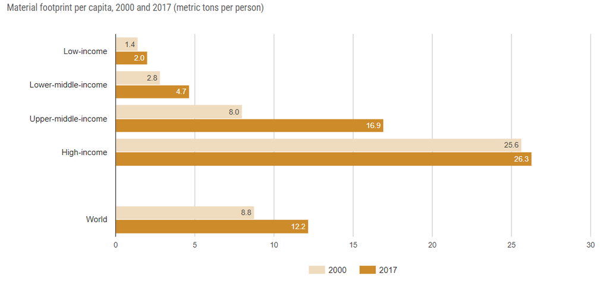

Figure 1. Material footprint per capita (tonnes) from 2000 to 2017, across varying income levels and the global average (UNSD, n.d.).

With extreme poverty rate as our explanatory variable, and the established relationship between income and material footprint, it is safe to assume that our linear relationship will follow a similar trend. As extreme poverty percentage increases, it is expected that material consumption will decrease.

```r
library(tidyverse)
library(broom)
library(kableExtra)
poverty_data<-read_csv("extreme_poverty_percent_people_below_215_a_day.csv")

footprint_date<-read.csv("matfootp_cap.csv")
```

## 1.1 Cleaning, Pivoting, and Joining

The two datasets did not include information from the same period of years. However, both included data from 1970 to 2019, so these years were selected for analysis. Additionally, the data was originally in a wide format, so both were pivoted into a longer format in order to only have columns representing “country”, “year”, and “percentage of people below $2.15 a day” or “material footprint per capita (tonnes)” respectively. The material footprint dataset also had a “X” string before each year, which had to be removed in order to be properly joined with the poverty dataset’s year variable. Once both datasets were formatted, they were joined off of the “country” and “year” variables to synthesize them into one dataset, now including both variables of interest. All n/a values were then filtered out of the new dataset. Finally, both of the variables of interest were converted to numeric in order to ensure that a quantitative linear analysis would function properly.

```r
poverty_data <- poverty_data |>
  select(country, "1970":"2019") |>
  pivot_longer(cols = "1970":"2019",
               names_to = "year",
               values_to = "% people below $2.15 a day")
```

```r
footprint_date <- footprint_date |>
  rename_with(~ str_remove(., "^X")) |>
  pivot_longer(cols = "1970":"2019",
               names_to = "year",
               values_to = "material footprint per capita (tonnes)") |>
  full_join(poverty_data, join_by(country, year)) |>
  filter(!is.na(`% people below $2.15 a day`)) |>
  filter(!is.na(`material footprint per capita (tonnes)`)) |>
  mutate(`% people below $2.15 a day` =
           as.numeric(`% people below $2.15 a day`)) |>
  mutate(`material footprint per capita (tonnes)` =
           as.numeric(`material footprint per capita (tonnes)`)) |>
  mutate(year =
           as.numeric(year))
```

# 2 Linear Regression

## 2.1 Data Visualization

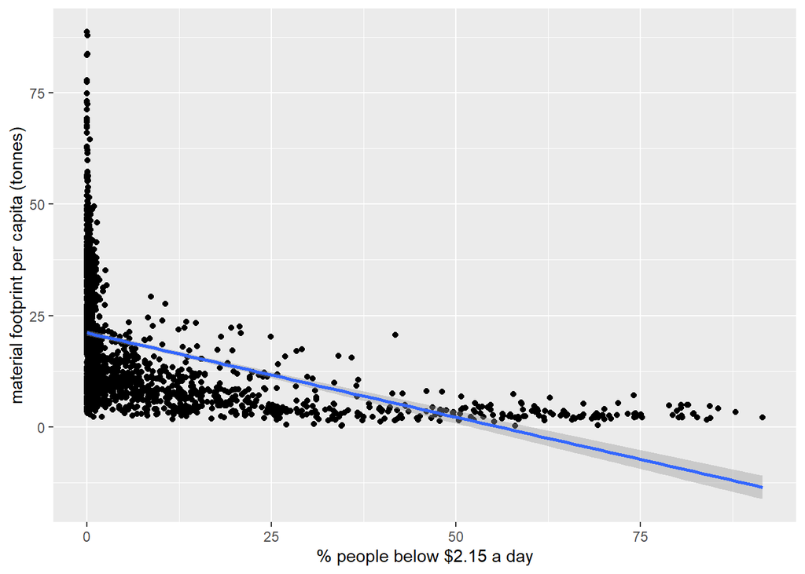

```r
first_model <- footprint_date |>
  ggplot(aes(x = `% people below $2.15 a day`,
             y = `material footprint per capita (tonnes)`)) +
  geom_point() +
  geom_smooth(method = "lm", formula = y ~ x)
first_model
```

```r
lin_mod1 <-
  lm(`material footprint per capita (tonnes)` ~ `% people below $2.15 a day`, data = footprint_date)
summary(lin_mod1)
```

```
Call:
lm(formula = `material footprint per capita (tonnes)` ~ `% people below $2.15 a day`,
    data = footprint_date)

Residuals:
    Min      1Q  Median      3Q     Max
-18.583  -8.738  -3.061   6.423  67.556

Coefficients:
                             Estimate Std. Error t value Pr(>|t|)
(Intercept)                  21.14387    0.31662   66.78   <2e-16 ***
`% people below $2.15 a day` -0.37897    0.01621  -23.37   <2e-16 ***
---
Signif. codes:  0 '***' 0.001 '**' 0.01 '*' 0.05 '.' 0.1 ' ' 1

Residual standard error: 11.91 on 1840 degrees of freedom
Multiple R-squared:  0.2289,    Adjusted R-squared:  0.2285
F-statistic: 546.3 on 1 and 1840 DF,  p-value: < 2.2e-16
```

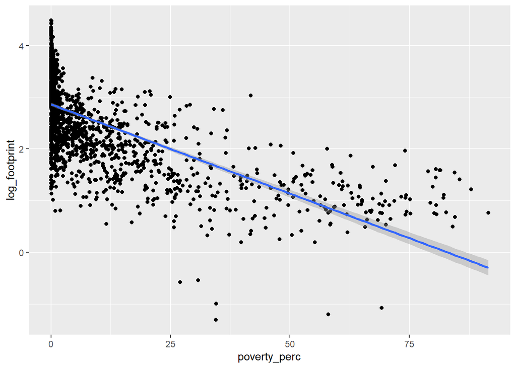

```r
footprint_date_new <- footprint_date |>
  rename(footprint = `material footprint per capita (tonnes)`,
         poverty_perc = `% people below $2.15 a day`) |>
  mutate(log_footprint = log(footprint))

  log_model <- footprint_date_new |>
  ggplot(aes(x = poverty_perc,
             y = log_footprint)) +
  geom_point() +
  geom_smooth(method = "lm", formula = y ~ x)
log_model
```

```r
lin_mod_log <-
  lm(log_footprint ~ poverty_perc, data = footprint_date_new)
summary(lin_mod_log)
```

```
Call:
lm(formula = log_footprint ~ poverty_perc, data = footprint_date_new)

Residuals:
     Min       1Q   Median       3Q      Max
-2.98037 -0.44798  0.02619  0.49595  1.65827

Coefficients:
               Estimate Std. Error t value Pr(>|t|)
(Intercept)   2.8626876  0.0173076  165.40   <2e-16 ***
poverty_perc -0.0345406  0.0008863  -38.97   <2e-16 ***
---
Signif. codes:  0 '***' 0.001 '**' 0.01 '*' 0.05 '.' 0.1 ' ' 1

Residual standard error: 0.651 on 1840 degrees of freedom
Multiple R-squared:  0.4522,    Adjusted R-squared:  0.4519
F-statistic:  1519 on 1 and 1840 DF,  p-value: < 2.2e-16
```

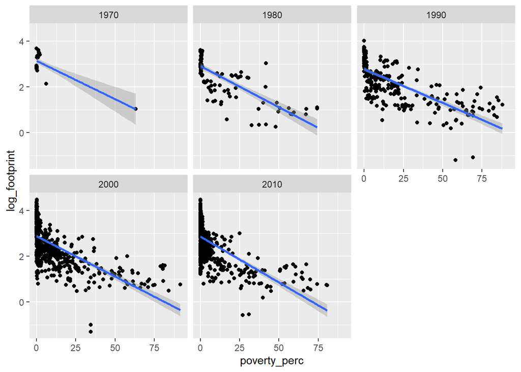

```r
plot_time <- footprint_date_new |>
  mutate(decade =  10 * floor(year/10)) |>
  ggplot(aes(x = poverty_perc,
             y = log_footprint)) +
  geom_point() +
  geom_smooth(method = lm, formula = y ~ x) +
  facet_wrap(~ decade)
plot_time
```

## 2.2 Linear Regression

```r
footprint_data_regression <- footprint_date_new %>%
  group_by(country) %>%
  summarise(
    avg_footprint = mean(footprint, na.rm = TRUE),
    avg_poverty_perc = mean(poverty_perc, na.rm = TRUE)
  )

lin_mod <- lm(avg_footprint ~ avg_poverty_perc, data = footprint_data_regression)

# Summary of the linear regression model
summary(lin_mod)
```

```
Call:
lm(formula = avg_footprint ~ avg_poverty_perc, data = footprint_data_regression)

Residuals:
    Min      1Q  Median      3Q     Max
-15.647  -7.610  -1.670   4.163  51.465

Coefficients:
                 Estimate Std. Error t value Pr(>|t|)
(Intercept)      19.33268    1.15878  16.684  < 2e-16 ***
avg_poverty_perc -0.32689    0.04143  -7.891 8.06e-13 ***
---
Signif. codes:  0 '***' 0.001 '**' 0.01 '*' 0.05 '.' 0.1 ' ' 1

Residual standard error: 10.68 on 139 degrees of freedom
Multiple R-squared:  0.3094,    Adjusted R-squared:  0.3044
F-statistic: 62.26 on 1 and 139 DF,  p-value: 8.055e-13
```

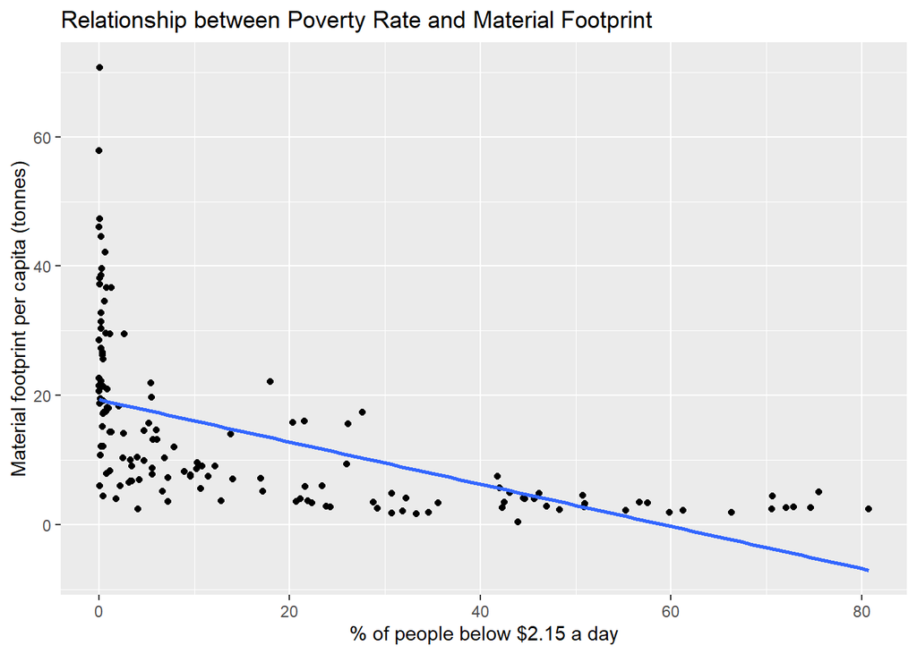

```r
ggplot(footprint_data_regression, aes(x = avg_poverty_perc, y = avg_footprint)) +
  geom_point() +
  geom_smooth(method = "lm", formula = y ~ x, se = FALSE) +
  labs(x = "% of people below $2.15 a day",
       y = "Material footprint per capita (tonnes)",
       title = "Relationship between Poverty Rate and Material Footprint")
```

### 2.2.1 Interpretation of the Regression Model

The linear regression model can be expressed as:

Material footprint per-capita of a country = 19.33268 - (0.32689 for every 1% more of people who earn below $2.15 per day) + error term

From the summary of the model, we get the estimates for 𝛽0 (intercept) and 𝛽1 (slope) as shown in the summary(lin_mod) output above. To simplify our analysis, each country’s poverty percentage and footprint were averaged over time, so each country only had one x and one y value.

Interpretation:

- **Intercept** (β0) of 19.33268: This represents the estimated material footprint per capita when the poverty rate is 0%. It provides the baseline material footprint regardless of the poverty rate. This number does not have any material meanings as the intercept for a regression equation is just a mathematical modeling tool
- **Slope** (𝛽1) of -0.32689: This indicates the change in material footprint per capita for each one percentage point increase in the poverty rate. A negative β1 suggests that as the poverty rate increases, the material footprint per capita decreases, which aligns with the hypothesis that poorer countries consume fewer materials per capita.

## 2.3 Model Fit

### 2.3.1 Calculate variances

```r
response_variance <- var(footprint_date_new$log_footprint)
fitted_values <- fitted(lin_mod_log)
fitted_variance <- var(fitted_values)
residuals_variance <- var(residuals(lin_mod_log))
```

### 2.3.2 Data frame for the variances

```r
variance_table <- data.frame(  `Variance Type` = c("Response Values", "Fitted Values", "Residuals"),  `Variance` = c(response_variance, fitted_variance, residuals_variance))
```

### 2.3.3 Table

```r
variance_table |>  kable("html", col.names = c("Variance Type", "Variance"), digits = 4) |>
kable_styling(full_width = F, bootstrap_options = c("striped", "hover", "condensed", "responsive"))|>
row_spec(0, bold = TRUE, color = "white", background = "turquoise")
```

| Variance Type | Variance |
| --- | --- |
| Response Values | 0.7733 |
| Fitted Values | 0.3497 |
| Residuals | 0.4236 |

### 2.3.4 Get the R-squared value

```r
r_squared <- summary(lin_mod_log)$r.squared
```